# FigureYa122mut2expr

### b右侧图：

###Right side image:

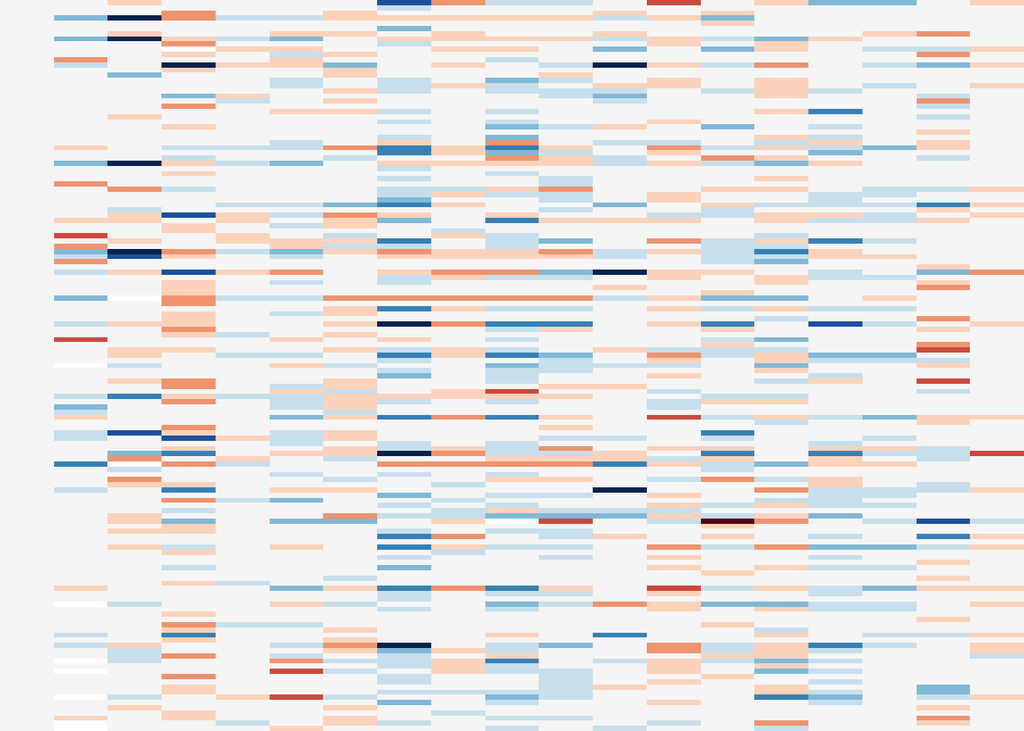

```r
# 设置绘图参数，包括无边框、坐标轴标签位置、边距等
# Set plot parameters including no border, axis label positions, margins, etc.
par(bty="n", mgp = c(2,.33,0), mar=rep(0,4), las=1, tcl=-.25, xpd=NA)

# 创建一个空绘图区域，设置x轴为设计矩阵的列数减1(排除第一列)，y轴为1000个基因
# Create an empty plot area with x-axis set to number of columns in design matrix minus 1 (excluding first column),
# y-axis set to 1000 genes
plot(NA, NA, xlim=c(0, ncol(design)-1), ylim=c(0, 1000),
     xaxt="n", yaxt="n", xlab="", ylab="", xaxs="i", yaxs="i")

# 创建热图：将线性模型系数矩阵(glm$coefficients)中的前1000个基因与突变类型的关系
# 映射到红-蓝(RdBu)颜色渐变，使用之前的聚类结果排序后绘制
# 颜色表示基因表达与突变类型之间的关联强度(-3到3之间分为12个等级)
# Create a heatmap: visualize the relationship between the top 1000 genes and mutation types
# using linear model coefficients (glm$coefficients)
# Map values to a red-blue (RdBu) color gradient, sort by previous clustering results, and plot
# Colors represent the strength of association between gene expression and mutation types
# (divided into 12 levels between -3 and 3)
rasterImage(matrix(brewer.pal(11, "RdBu")[cut(glm$coefficients[w, -1][h$order, j$order], seq(-3, 3, length.out=12))],
                   ncol=ncol(design)-1),
            0, 0, ncol(design)-1, 1000, interpolate=FALSE)
```

## c和d

仅用b图的heatmap回答基因表达如何响应不同的genotype以及各种不同的突变如何影响基因表达还不够完美，作者又画了c和d图。

原文代码用baseplot画c和d图，我自己用ggplot2复现了c和d图。

##C and D

It is not perfect to answer how gene expression responds to different genotypes and how various mutations affect gene expression using only the heatmap in Figure B. The author has also drawn Figures C and D.

The original code used baseplot to draw c and d graphs, and I reproduced the c and d graphs myself using ggplot2.

```r
# 创建一个包含Set1和Dark2调色板颜色的向量，用于后续绘图的颜色设置
# Create a vector of colors from Set1 and Dark2 palettes for use in subsequent plots
set1 = c(brewer.pal(9,"Set1"), brewer.pal(8, "Dark2"))

# 加载外部R脚本"mg14.R"，该脚本来自https://github.com/mg14/mg14仓库
# 该脚本可能包含自定义函数或分析流程
# Source an external R script "mg14.R" from https://github.com/mg14/mg14 repository
# This script likely contains custom functions or analysis pipelines
source("mg14.R")
```

### 1. Construct random phenotype data.

The method is the same as “building a linear model” above, except that phenotype data, i.e. genotype data, is randomly selected to demonstrate that genotype differences have an impact on gene expression values. But this part does not consider the later “Normal”, “Gender”, “Age”, etc., so columns 2-17 in glm are used (here I think the original 2:16 is incorrect because there is no del (20q) column because there are 17 mutant information, and carefully looking at the figures in the original text and the figures provided in the supplementary materials are different, so there is no need to worry too much here, understanding the code principle is the most important)

```r
# 重新计算F统计量，仅考虑线性模型中第2到17列的变量（通常是突变类型相关变量）
# Recompute F-statistics considering only variables in columns 2 to 17 of the linear model
# (typically mutation type-related variables)
F.stat <- classifyTestsF(glm[,2:17], fstat.only=TRUE)

# 设置随机数种子以确保结果可重现
# Set random seed for reproducibility
set.seed(42)

# 构建随机化对照模型：对设计矩阵的每一列进行随机重排，破坏变量与样本的真实关联
# 然后拟合线性模型并进行经验贝叶斯调节
# Build a randomized control model: randomly permute each column of the design matrix to disrupt
# the true association between variables and samples, then fit a linear model and apply empirical Bayes
rlm <- lmFit(geneExpr[, rownames(design)], apply(design, 2, sample))
rlm <- eBayes(rlm)

# 计算随机化模型的F统计量，用于评估观察到的F统计量的显著性
# Compute F-statistics for the randomized model to assess the significance of observed F-statistics
R.stat <- classifyTestsF(rlm[,2:17], fstat.only=T)
```

到这里为止，我们有两个 t-statistics数值，分别为F.stat和R.stat，分别代表真实的基因型对基因表达的影响和随机出来的基因型对表达的影响。F.stat的官方解释是：For each gene, classify a series of related t-statistics as significantly up or down using nested F-tests。也就是说，对于一个基因来说，F.stat越大，不同的基因型之间表达差异越明显，so基因型是对这个基因是决定因素的可能性越大。

So far, we have two t-statistics values, F.stat and R.stat, representing the impact of real genotypes on gene expression and the impact of randomly selected genotypes on expression, respectively. F. The official explanation of stat is: For each gene, classify a series of related t-statistics as significantly up or down using nested F-tests。 That is to say, for a gene, the larger the F.stat, the more significant the expression differences between different genotypes, and the greater the possibility that genotype is the determining factor for this gene.

### 2. 计算基因型差异和表达差异之间的R平方。

实话实说作者的计算公式没太理解。一般来讲计算R平方R2=SSR/SST=1-SSE/SST，其中：SST=SSR+SSE，SST(total sum of squares)为总平方和，SSR(regression sum of squares)为回归平方和，SSE(error sum of squares) 为残差平方和。这里的代码是：

### 2. Calculate the R-squared between genotype differences and expression differences.

To be honest, the author didn’t quite understand the calculation formula. Generally speaking, calculating R-squared R2=SSR/SST=1-SSE/SST, where SST=SSR+SSE, SST (total sum of squares) is the total sum of squares, SSR (regression sum of squares) is the regression sum of squares, and SSE (error sum of squares) is the residual sum of squares. The code here is:

```r
# 基于F统计量计算遗传效应的R²值（解释方差比例）
# 使用公式 R² = 1 - 1/(1 + F·df1/df2)，其中df1=15（突变类型数），df2=n-p（样本数-参数数）
# Calculate R-squared values (proportion of variance explained) for genetic effects based on F-statistics
# Using the formula R² = 1 - 1/(1 + F·df1/df2), where df1=15 (number of mutation types), df2=n-p (number of samples minus number of parameters)
Rgenetics = 1 - 1/(1 + F.stat * 15/(nrow(design)-ncol(design)))

# 基于随机化模型的F统计量计算零分布下的R²值
# 用于评估观察到的Rgenetics的显著性
# Calculate R-squared values under the null distribution using F-statistics from the randomized model
# Used to assess the significance of observed Rgenetics values
Pgenetics = 1 - 1/(1 + R.stat * 15/(nrow(design)-ncol(design)))

# 为R²值向量命名，使其与基因表达矩阵的行名(基因ID)对应
# Name the R-squared vectors to match the row names (gene IDs) of the gene expression matrix
names(Rgenetics) <- names(Pgenetics) <- rownames(geneExpr)
```

Rgenetics正式基因型数据；Pgenetics随机基因型数据。

### 3. 寻找adjust.p值小于0.05的基因（相关性最强的基因）

Regenetics official genotype data; Pgenetics random genotype data.

### 3. Search for genes with an adjust.P value less than 0.05 (the genes with the strongest correlation)

```r
# 从F统计量对象中提取分子自由度和分母自由度
# 这两个参数用于后续的F检验和p值计算
# Extract degrees of freedom (numerator and denominator) from the F-statistic object
# These parameters are used for subsequent F-tests and p-value calculations
df1 <- attr(F.stat, "df1")
df2 <- attr(F.stat, "df2")

# 基于F统计量计算p值，使用卡方分布近似（F统计量乘以分子自由度近似服从卡方分布）
# Calculate p-values based on F-statistics using a chi-squared distribution approximation
# (F-statistic multiplied by numerator degrees of freedom approximates a chi-squared distribution)
F.p.value <- pchisq(df1 * F.stat, df1, lower.tail = FALSE)

# 计算多重检验校正后的q值（使用Benjamini-Hochberg方法控制FDR）
# 筛选q值小于0.05的显著基因，并找出其中最小的Rgenetics值
# 该值作为后续分析中"显著可解释方差"的阈值
# Calculate q-values using Benjamini-Hochberg method to control FDR
# Select significant genes with q-value < 0.05 and find the minimum Rgenetics value among them
# This value serves as the threshold for "significantly explained variance" in subsequent analyses
r <- min(Rgenetics[p.adjust(F.p.value, "BH") < 0.05])
```

前三步为计算p值。r：adjust.p <0.05的最小的Rgenetics(相关系数)的值.我们认为Rgenetics大于r的基因都是和突变有相关性的基因。

The first three steps are to calculate the p-value. r: The minimum value of Rgenetics (correlation coefficient) with adjustment. p<0.05 We believe that genes with Rgenetics greater than r are genes associated with mutations.

### 4. 原文画c图的代码

### 4. The code for drawing a C diagram in the original text

```r
# 设置绘图参数，包括无边框、坐标轴标签位置、边距等
# Set plot parameters including no border, axis label positions, margins, etc.
par(bty="n", mgp = c(2,.33,0), mar=c(3,2.5,1,1)+.1, las=1, tcl=-.25, xpd=NA)

# 计算随机模型解释方差(Pgenetics)的密度分布
# Compute the density distribution of explained variance from the randomized model (Pgenetics)
d <- density(Pgenetics, bw=1e-3)

# 定义缩放因子(原文中由nrow(gexpr)/512得到)
# Define scaling factor (derived from nrow(gexpr)/512 in the original code)
f <- 1

# 绘制随机模型的密度曲线(灰色)，x轴为解释方差(R²)，y轴为密度
# Plot the density curve of the randomized model (grey), x-axis is explained variance (R²), y-axis is density
plot(d$x, d$y * f, col='grey', xlab=expression(paste("Explained variance per gene ", R^2)),
     main="", lwd=2, type="l", ylab="", xlim=c(0,0.7))
title(ylab="Density", line=1.5)  # 添加y轴标签

# 计算实际模型解释方差(Rgenetics)的密度分布
# Compute the density distribution of explained variance from the actual model (Rgenetics)
d <- density(Rgenetics, bw=1e-3)

# 找出密度曲线中解释方差大于阈值r的部分
# Find the part of the density curve where explained variance exceeds the threshold r
x0 <- which(d$x > r)

# 填充实际模型中超过阈值r的区域(使用半透明红色)
# Shade the area under the density curve where Rgenetics exceeds the threshold r (using translucent red)
polygon(d$x[c(x0[1], x0)], c(0, d$y[x0]) * f, col=paste(set1[1], "44", sep=""), border=NA)

# 绘制实际模型的密度曲线(红色)
# Plot the density curve of the actual model (red)
lines(d$x, d$y * f, col=set1[1], lwd=2)

# 添加文本标注：显示超过阈值r的基因数量
# Add text annotation: number of genes with Rgenetics exceeding threshold r
text(d$x[x0[1]], d$y[x0[1]] * f, pos=4, paste(sum(Rgenetics > r), "genes q < 0.05"))

# 添加箭头指向ENTREZID为22的基因(ABCB7)
# Add an arrow pointing to the gene with ENTREZID 22 (ABCB7)
arrows(Rgenetics["22"], par("usr")[4]/7, Rgenetics["22"], par("usr")[4]/50, length=0.05)

# 找出解释方差最高的基因并显示前几个
# Find genes with the highest explained variance and display the top ones
M_Rgenetics <- sort(Rgenetics, decreasing=T)
head(M_Rgenetics)
```

```
##        22     11138     23168      9897     79632     22925
## 0.5863966 0.5549236 0.5175969 0.5175446 0.5041090 0.4914301
```

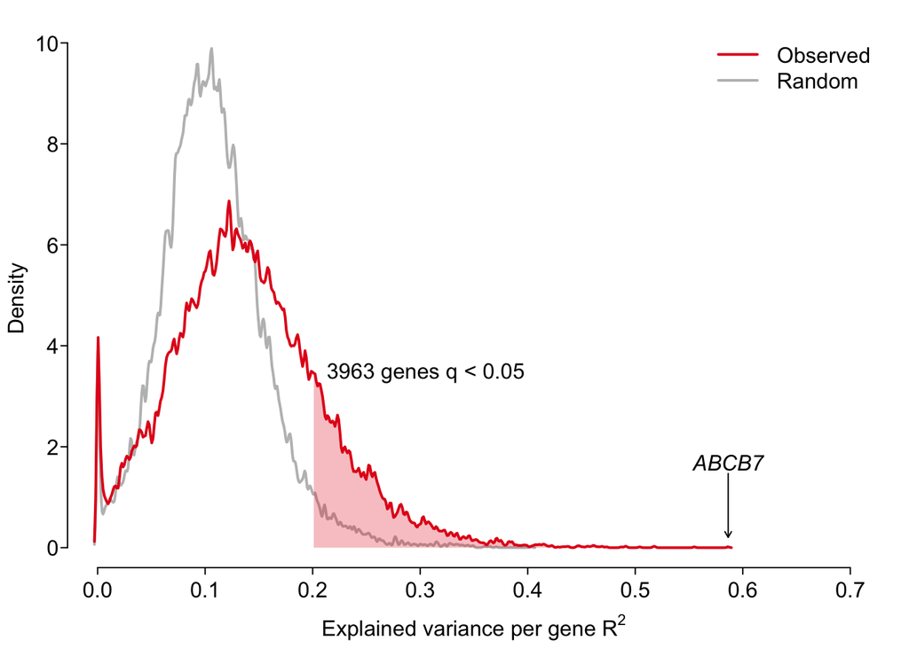

```r
# 标注ABCB7基因(ENTREZID 22)及其解释方差值
# Label the ABCB7 gene (ENTREZID 22) and its explained variance value
text(Rgenetics["22"], par("usr")[4]/8, "ABCB7", font=3, pos=3)

# 添加图例说明不同曲线的含义
# Add legend to explain different curves
legend("topright", bty="n", col=c(set1[1], "grey"), lty=1, c("Observed", "Random"), lwd=2)
```

### 5. 原文画d图的代码

首先通过上面得到的线性模型预测一下基因表达水平。首先是预测所有的基因和突变的关系。这里涉及到一个“%*%”，这个代表矩阵相乘的含义。矩阵相乘是第一个矩阵的row* 第二个矩阵column的和。

### 5. The code for drawing a diagram in the original text

Firstly, predict the gene expression level using the linear model obtained above. The first step is to predict the relationship between all genes and mutations. This involves a ’% *%’, which represents the meaning of matrix multiplication. Matrix multiplication is the sum of the row of the first matrix and the column of the second matrix.

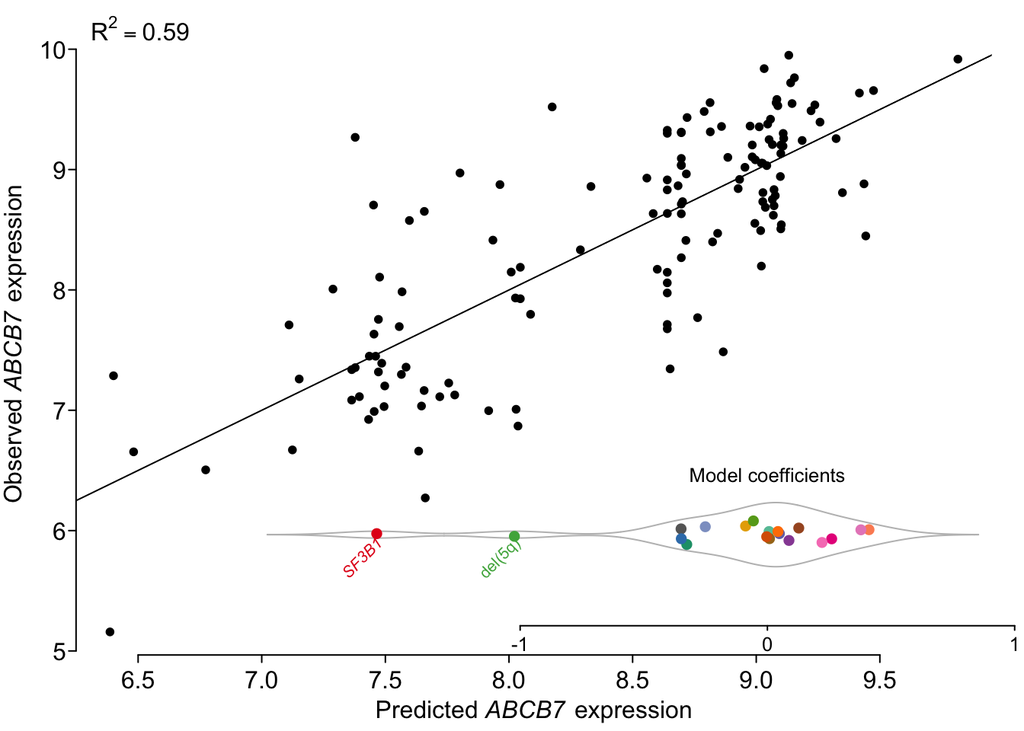

```r
# 基于线性模型系数和设计矩阵预测所有基因的表达值
# 矩阵乘法结果：基因数×样本数，每行代表一个基因在所有样本中的预测表达
# Predict gene expression values using linear model coefficients and design matrix
# Result of matrix multiplication: number of genes × number of samples
glmPrediction <- glm$coefficients %*% t(design)

# 设置绘图参数，包括无边框、坐标轴标签位置、边距等
# Set plot parameters including no border, axis label positions, margins, etc.
par(bty="n", mgp = c(1.5,.33,0), mar=c(2.5,2.5,1,1)+.1, las=1, tcl=-.25)

# 绘制ABCB7基因(ENTREZID 22)的预测表达值与实际表达值的散点图
# 横坐标：预测表达值，纵坐标：实际表达值，共有141个样本点
# Scatter plot of predicted vs. observed expression values for ABCB7 gene (ENTREZID 22)
# X-axis: predicted expression, Y-axis: observed expression, 141 samples in total
plot(glmPrediction["22",], geneExpr["22", rownames(design)],
     ylab=expression(paste("Observed ", italic("ABCB7"), " expression")),
     xlab=expression(paste("Predicted ", italic("ABCB7"), " expression")),
     pch=16, cex=.8)

# 添加y=x参考线，表示预测完全准确的情况
# Add y=x reference line indicating perfect prediction
abline(0,1)

# 准备在主图右下方添加小图：展示ABCB7基因与各基因型的相关性分布
# Prepare to add an inset plot showing correlation distribution between ABCB7 and genotypes
y <- glm$coefficients["22", -1] + glm$coefficients["22", 1]  # 获取ABCB7与各基因型的关联系数
u <- par("usr")  # 获取当前绘图区域坐标
par(xpd=NA)  # 允许图形元素超出绘图区域

# 计算小图中各点的位置坐标
# Calculate coordinates for points in the inset plot
x0 <- rep(u[3] + 1, ncol(design) - 1)  # x坐标固定在主图左侧
y0 <- u[4] + 0.05 * (u[4] - u[3]) - rank(-y) / length(y) * (u[4] - u[3]) / 1.2  # y坐标按系数排序

# 计算ABCB7与各基因型关联系数的密度分布
# Compute density distribution of correlation coefficients between ABCB7 and genotypes
d <- density(y)

# 绘制关联系数的密度分布轮廓(类似小提琴图)
# Draw density distribution outline (similar to violin plot)
lines(d$x, d$y/5 + 1 + u[3], col="grey")
lines(d$x, -d$y/5 + 1 + u[3], col="grey")

# 在密度分布区域内绘制各基因型的关联系数点，使用不同颜色区分基因型
# Plot correlation coefficients for each genotype with different colors
points(x = y, y = x0 + violinJitter(y, magnitude = 0.25)$y, col = colMutations, pch = 16)

# 添加标题：模型系数
# Add title: Model coefficients
text(x = glm$coefficients["22", 1], y = 1.5 + u[3], "Model coefficients", cex = 0.8)

# 找出与ABCB7最相关的基因型(p值<0.01)
# Identify genotypes most significantly associated with ABCB7 (p-value < 0.01)
w <- glm$p.value["22", -1] < 0.01

# 为显著相关的基因型添加旋转标签
# Add rotated labels for significantly associated genotypes
rotatedLabel(y[w], x0[w] + 0.1, labels = colnames(design)[-1][w],
             font = ifelse(grepl("[[:lower:]]", colnames(design)[-1]), 1, 3)[w],
             cex = .66, pos = 1, col = colMutations[w])

# 添加x轴刻度，显示相对于截距的系数值
# Add x-axis ticks showing coefficient values relative to the intercept
axis(at = -1:1 + glm$coefficients["22", 1], labels = -1:1, side = 1,
     cex.axis = .8, line = -1, mgp = c(1.5, .05, 0), tcl = -.15)

# 在图的右上角添加R²值，表示模型对ABCB7表达的解释程度
# Add R² value in the top-right corner, indicating the proportion of variance explained
text(u[1], u[4], substitute(paste(R^2 == r), list(r = round(Rgenetics["22"], 2))), pos = 4)
```

### 6. 用ggplot2画c和d图

构建数据

### 6. Use ggplot2 to draw graphs c and d

Building data

```r
# 加载ggplot2包，用于创建高质量统计图形
# Load the ggplot2 package for creating high-quality statistical graphics
library(ggplot2)

# 创建数据框，包含观察到的解释方差(Rgenetics)和随机模型的解释方差(Pgenetics)
# Create a data frame containing observed explained variance (Rgenetics) and
# explained variance from the random model (Pgenetics)
genetics <- data.frame(Observed = Rgenetics, Random = Pgenetics)

# 根据阈值r标记显著基因和非显著基因
# Label significant and non-significant genes based on threshold r
for (i in 1:nrow(genetics)) {
  if (genetics[i, 1] > r) {
    genetics[i, 3] <- "sign"
  } else {
    genetics[i, 3] <- "nc"
  }
}
```

画图

plot

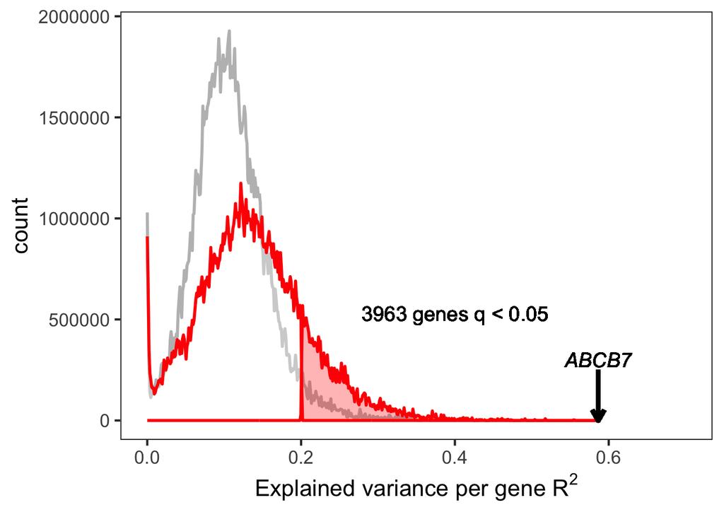

```r
# 使用ggplot2创建解释方差密度图，比较观察值与随机模型的分布差异
# Create a density plot of explained variance using ggplot2 to compare observed vs. random distributions
ggplot(genetics) +

  # 绘制随机模型解释方差的密度曲线(灰色)
  # Plot density curve for explained variance from the random model (grey)
  geom_density(aes(Random, stat(count)), col="grey", adjust=0.01, size=1) +

  # 绘制观察到的解释方差的密度曲线(红色)，并按显著性分组填充颜色
  # Plot density curve for observed explained variance (red) with color fill by significance
  geom_density(aes(Observed, stat(count), fill=V3), col="red", adjust=0.01, size=1, alpha=0.3) +

  # 添加文本标注，显示显著基因数量(q<0.05)
  # Add text annotation showing the number of significant genes (q<0.05)
  geom_text(aes(r+0.2, 530000), label= paste(sum(Rgenetics > r), "genes q < 0.05"), size=5) +

  # 添加箭头指向ABCB7基因的解释方差值
  # Add an arrow pointing to the explained variance value of ABCB7 gene
  geom_segment(aes(x=Rgenetics["22"], xend=Rgenetics["22"], y=250000, yend=1),
               size=1.5, arrow=arrow(length=unit(0.3, "cm"))) +

  # 添加ABCB7基因标签
  # Add label for ABCB7 gene
  geom_text(aes(Rgenetics["22"], 300000), label="ABCB7", size=5, fontface="italic") +

  # 手动设置显著性分组的填充颜色(非显著=白色，显著=红色)
  # Manually set fill colors for significance groups (non-significant=white, significant=red)
  scale_fill_manual(values=c("white", "red")) +

  # 设置x轴标签为解释方差(R²)
  # Set x-axis label to explained variance (R²)
  labs(x=expression(paste("Explained variance per gene ", R^2))) +

  # 使用黑白主题并设置基础字体大小
  # Use black-and-white theme with specified base font size
  theme_bw(base_size=16) +

  # 移除网格线并隐藏图例
  # Remove grid lines and hide legend
  theme(panel.grid=element_blank(), legend.position="none") +

  # 设置x轴显示范围为0到0.7
  # Set x-axis limits from 0 to 0.7
  coord_cartesian(xlim=c(0, 0.7))
```

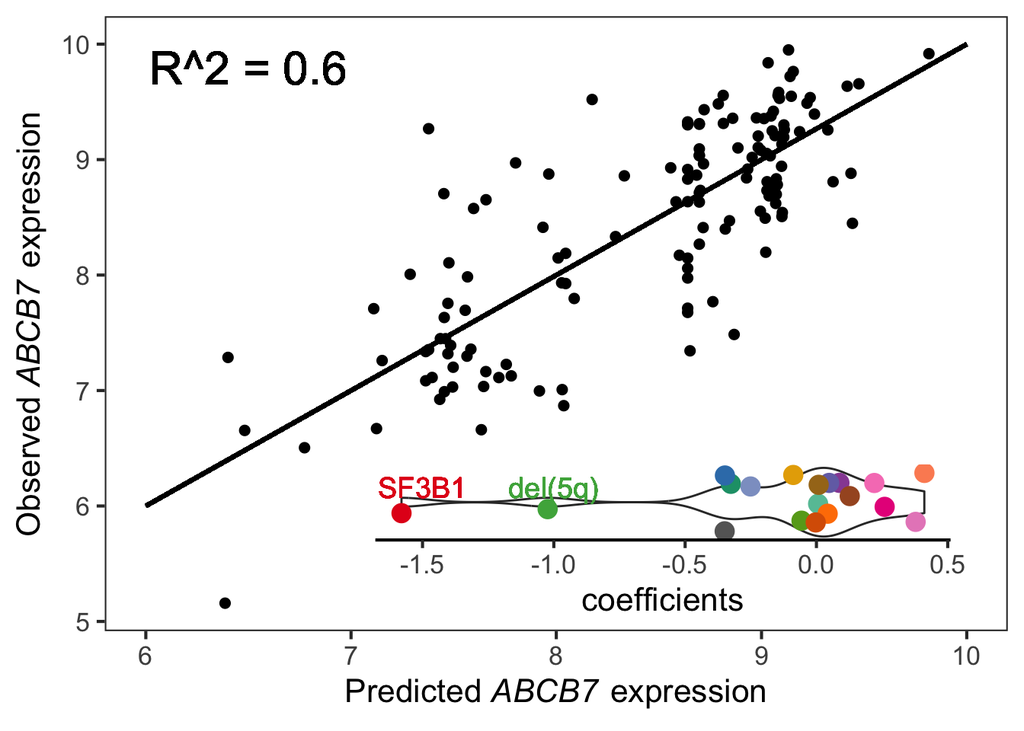

```r
# 创建数据框，包含ABCB7基因的预测表达值和实际观测值
# Create a data frame containing predicted and observed expression values for ABCB7 gene
expr <- data.frame(Predict = glmPrediction["22",], Observed = geneExpr["22", rownames(design)])

# 创建小提琴图所需的数据框，包含ABCB7与各基因型的关联系数
# Create data frame for violin plot containing association coefficients between ABCB7 and genotypes
vio_data <- as.data.frame(glm$coefficients["22", -1])
colnames(vio_data) <- "coefficients"
vio_data$color <- rownames(vio_data)

# 创建预测值与观测值的散点图
# Create scatter plot of predicted vs. observed expression values
p1 <- ggplot(expr, aes(Predict, Observed)) +
  geom_point(size=2) +
  geom_segment(aes(x=6, xend=10, y=6, yend=10), size=1) +
  labs(x=expression(paste("Predicted ", italic("ABCB7"), " expression")),
       y=expression(paste("Observed ", italic("ABCB7"), " expression"))) +
  geom_text(aes(6.5, 9.8, label="R^2 = 0.6"), size=8) +
  theme_bw(base_size=16) +
  theme(panel.grid=element_blank(), legend.position="none")

# 为小提琴图数据添加颜色标签（基因型名称）
# Add color labels (genotype names) to violin plot data
vio_data$color <- rownames(vio_data)

# 创建关联系数的小提琴图
# Create violin plot of association coefficients
p2 <- ggplot(vio_data, aes(x=1, y=coefficients)) +
  geom_violin(bw=0.1) +
  geom_jitter(aes(color=color), size=4) +
  geom_text(aes(1.2, -1.5), label="SF3B1", size=5, col=colMutations["SF3B1"]) +
  geom_text(aes(1.2, -1), label="del(5q)", size=5, col=colMutations["del(5q)"]) +
  coord_flip() +
  scale_color_manual(values=colMutations) +
  theme_classic(base_size=16) +
  theme(panel.grid=element_blank(), legend.position="none",
        axis.title.y=element_blank(),
        axis.text.y=element_blank(),
        axis.ticks.y=element_blank(),
        axis.line.y=element_blank())

# 使用cowplot包将两个图组合在一起
# Combine the two plots using cowplot package
library(cowplot)
p1 +
  annotation_custom(ggplotGrob(p2),
                    xmin=7, ymin=4.9, xmax=10, ymax=6.5)
```